# g.simulation

Dennis Kim

2024-01-30

# Document Preamble

```r
# load libraries
library(knitr)
library(readr)
library(data.table)
library(here)
library(purrr)
library(lubridate)
library(scales)
library(conflicted)
library(tidyverse)
library(scico)
library(patchwork)
library(tictoc)

# call environmental data
library(terra)
library(sf)

# analysis
library(amt)
library(MASS)
library(statip)

# visualization
library(ggplot2)
library(tidyterra)

options(width = 150)

conflict_prefer("select", "dplyr")
conflict_prefer("filter", "dplyr")
conflicts_prefer(lubridate::hour)
conflicts_prefer(terra::plot)
conflicts_prefer(dplyr::lag)
```

# call the shrub layers

```r
# observed shrub cover
shrub <- terra::rast("E:/oryx_hmm/data/shrub/final.shrub.tif")
```

# simulating tracks using the amt functions

1. specifying paamters governing the movements for the individual using the *make_issf_model()** function
2. specifying a redistribution kernel for generating movements based on an initial location and bearing
3. generating paths from the simulated redistribution kernel specified for a user-provided number of steps

visualize the movement parameter distribution per each state

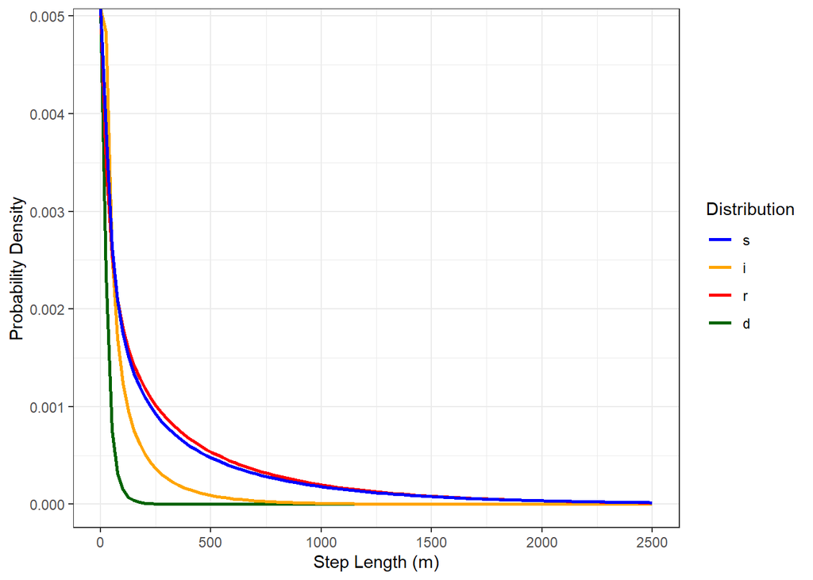

```r
# gamma distribution

## data for plotting
plot_sl <- data.frame(x = rep(NA, 100))

## x-axis is sequence of possible step lengths
plot_sl$x <- seq(from = 0, to = 2500, length.out = 100)

# y-axis is the prob density under the given gamma distribution

# Susceptible (S)
plot_sl$s <- dgamma(
  x = plot_sl$x,
  shape = 0.5,
  scale = 800
)

# Infected (I)
plot_sl$i <- dgamma(
  x = plot_sl$x,
  shape = 0.2,
  scale = 300
)

# Recovered (R)
plot_sl$r <- dgamma(
  x = plot_sl$x,
  shape = 0.6,
  scale = 700
)

# Dead (D)
plot_sl$d <- dgamma(
  x = plot_sl$x,
  shape = 0.1,
  scale = 50
)

# pivot from wide data to long data
plot_sl <- plot_sl %>% pivot_longer(cols = -x)


# plot
ggplot(plot_sl, aes(x = x, y = value, color = factor(name)))+
  geom_line(size = 1)+
  xlab("Step Length (m)")+
  ylab("Probability Density")+
  scale_color_manual(name = "Distribution",
                     breaks = c("s", "i", "r", "d"),
                     values = c("blue", "orange", "red", "darkgreen"))+
  theme_bw()
```

prep for the simulation - in this vignette - due to the computational demanding, we only simulate 2 individuals for the demonstration. However, you can increase the number of individuals you would like to simulate with users’ choices of how long the simulation should last. In our paper, we simulated 20 individuals over 30 days.

```r
# covariance matrix for the movement parameters
sig <- matrix(c(0.4, 0.15, 0.15, 0.15, 0.3, 0.15, 0.15, 0.15, 0.4), ncol = 3, byrow = TRUE)

# parameter values
param.value_n <- data.frame(id = NA, shape = NA, scale = NA, kappa = NA) # non_infected
param.value_i <- data.frame(id = NA, shape = NA, scale = NA, kappa = NA) # infected

# number of individual (NOTE: you can increase the number of individuals - here we only simulate 2 individuals)
n_ind <- 2

# Initial start point
start <- make_start(c(runif(1, 300000, 360000), runif(1, 1600000, 1700000)), ta_ = 0)

# number of total steps to generate (NOTE: you can increase the number of days for the simulation - here we only simulate 10 days for the computational demands)
total_days <- 10
```

## transitional matrix - infection x behavioral states

prep for the recursive Markov chain manner for getting the infection & behavioral status (each is per day) and 24 steps per day since it is resampled by hourly.

```r
# Modify the code to use a 4x4 transitional probability matrix and track 4 different states daily.

# Define the transitional probability matrix for susceptible, infection, recovered, and dead
# susceptible --> susceptible or infected or natually dead
# infected --> infected or recovered or infected dead
# recovered --> only recovered
# dead --> only dead
trans_m <- matrix(c(
  0.65, 0.3, 0, 0.05,
  0, 0.45, 0.15, 0.4,
  0, 0, 1, 0,
  0, 0, 0, 1
), nrow = 4, ncol = 4, byrow = TRUE)

# Function: ReMC
# Description: This function represents a recursive representation of a Markov chain.
# Parameters:
#   - v: vector representing the initial state of the Markov chain
#   - n: integer representing the number of steps in the Markov chain
# Returns:
#   - A vector representing the state of the Markov chain after n steps

ReMC <- function(v, n) {
  # Base case: if n equals 1, return the initial state v
  if (n == 1) return(v)

  # Recursive step: compute the state of the Markov chain after n - 1 steps
  p <- ReMC(v, n - 1)

  # Extract the last element of the computed state vector
  u <- tail(p, 1)

  # Select the next state based on the transition matrix trans_m
  # Sample from a vector of states with probabilities determined by the transition matrix
  next_state <- sample(1:4, 1, prob = trans_m[u, ])

  # Concatenate the computed state vector with the next state
  # This represents the state of the Markov chain after n steps
  c(p, next_state)
}

# Define the initial state value - starting from the susceptible phase
x0 <- c(state = 1)  # Assuming the initial state is 1 (susceptible)

# Apply the ReMC function to the list of vectors representing the initial parameter values (NOTE: you can do this if you want to generate several individuals that have same state sequence - otherwise, generating unique set of state sequence - put it in the for-loop like below)
#state_info <- sapply(x0, ReMC, total_days)

# Display the state information
#print(state_info)
```

## simulate the paths

The provided code simulates the path of an individual with specified conditions and annotations. It incorporates a transitional probability matrix (tpm) to determine changes in infection status during each step of the simulation. Depending on the current infection status of the individual, the code selects the appropriate probability from the matrix to determine the next state. The simulation iterates through each step, updating the infection status accordingly and simulating the path based on the redistribution kernel.

```r
# tracking the simulation timing
start_time <- Sys.time()

# Create an empty list for all individuals
all_ssf <- vector("list", length = n_ind)

# Looping for transitions between states
for (ind in 1:n_ind) {

  # simulate a unique state sequence for this individual
  state_info <- ReMC(x0, total_days)

  # Temporary list for one individual's results
  ssf_sim <- vector("list", length = total_days)

  # Initialize start position for this individual
  start_position <- start

  # Model per group

  ## model 1 - susceptible
  m_s <- make_issf_model(coefs = c("sl_" = 0,
                                    "log(sl_)" = 0,
                                    "cos(ta_)" = 0),
                          sl = make_gamma_distr(shape = 0.5,
                                                scale = 800),
                          ta = make_vonmises_distr(kappa = 2))

  ## model 2 - infected
  m_i <- make_issf_model(coefs = c("sl_" = 0,
                                    "log(sl_)" = 0,
                                    "cos(ta_)" = 0),
                          sl = make_gamma_distr(shape = 0.2,
                                                scale = 300),
                          ta = make_vonmises_distr(kappa = 0.06))

  ## model 3 - recovered
  m_r <- make_issf_model(coefs = c("sl_" = 0,
                                    "log(sl_)" = 0,
                                    "cos(ta_)" = 0),
                          sl = make_gamma_distr(shape = 0.6,
                                                scale = 700),
                          ta = make_vonmises_distr(kappa = 0.1))

  ## model 4 - dead
  m_d <- make_issf_model(coefs = c("sl_" = 0,
                                    "log(sl_)" = 0,
                                    "cos(ta_)" = 0),
                          sl = make_gamma_distr(shape = 0.1,
                                                scale = 50),
                          ta = make_vonmises_distr(kappa = 0.58))

  # Redistribution kernel per group

  ## redistribution kernel - non-infected explore
  rdk_s <- redistribution_kernel(m_s,
                                  start = start,
                                  map = shrub,
                                  landscape = "continuous",
                                  tolerance = 0.02)

  ## redistribution kernel - non-infected resting
  rdk_i <- redistribution_kernel(m_i,
                                  start = start,
                                  map = shrub,
                                  landscape = "continuous",
                                  tolerance = 0.02)

  ## redistribution kernel - infected exploratory
  rdk_r <- redistribution_kernel(m_r,
                                  start = start,
                                  map = shrub,
                                  landscape = "continuous",
                                  tolerance = 0.02)

  ## redistribution kernel - infected resting
  rdk_d <- redistribution_kernel(m_d,
                                  start = start,
                                  map = shrub,
                                  landscape = "continuous",
                                  tolerance = 0.02)

  # Loop over each day for this individual
  for (i in 1:total_days) {
    state <- state_info[i]

    if (state == 1) {
      ssf_sim[[i]] <- data.frame(
        id = ind,
        state = state,
        positions = list(simulate_path(rdk_s, n.steps = 24, custom_start = start_position))
      )
    } else if (state == 2) {
      ssf_sim[[i]] <- data.frame(
        id = ind,
        state = state,
        positions = list(simulate_path(rdk_i, n.steps = 24, custom_start = start_position))
      )
    } else if (state == 3) {
      ssf_sim[[i]] <- data.frame(
        id = ind,
        state = state,
        positions = list(simulate_path(rdk_r, n.steps = 24, custom_start = start_position))
      )
    } else if (state == 4) {
      ssf_sim[[i]] <- data.frame(
        id = ind,
        state = state,
        positions = list(simulate_path(rdk_d, n.steps = 24, custom_start = start_position))
      )
    }

    # update start position for next step
    start_position <- tail(ssf_sim[[i]]$positions[[1]], 1)$position
  }

  # Save this individual's results into the master list
  all_ssf[[ind]] <- do.call(rbind, ssf_sim)
}
# Combine all individuals into one dataframe
ssf_df <- do.call(rbind, all_ssf)

# Remove duplicate positions if necessary
ssf_df <- ssf_df[!duplicated(ssf_df$positions.x_, ssf_df$positions.y_),]

# Now you should see multiple ids in the final dataset
unique(ssf_df$id)
```

```
## [1] 1 2
```

```r
# change the time order
positions.t <- seq(
  from = as.POSIXct("2024-02-05 20:27:26"),
  by   = "hour",
  length.out = 31 * 24  # 30 days * 24 hours
)

ssf_df1 <- ssf_df %>% group_by(id) %>% mutate(positions.t_ = positions.t[seq_len(n())]) %>% ungroup()

# save the data
#saveRDS(ssf_df1, "09.04.2025_20id_30days_SIR_simulation.rds")

end_time <- Sys.time()
runtime <- end_time - start_time
```

# Visualizations

visualization of the tracks:

```r
ssf_df <- readRDS(here::here("data/simulation", "09.04.2025_20id_30days_SIR_simulation.rds"))

# prep for sff_df
ssf_df$state <- as.factor(ssf_df$state)

# change the labels
state_names <- c('1' = "S", '2' = "I", '3' = "R", '4' = "D")
```

```r
# visualize the movement paths across behaviors
p <- ggplot()+
  geom_spatraster(data = shrub, show.legend = FALSE)+
  geom_point(data = ssf_df, aes(positions.x_, positions.y_), size = 0.7)+
  labs(title = "SIR simulation for 30 days (n=20)")+
  facet_wrap(~state,
             labeller = labeller(state = state_names),
             nrow = 1)+
  scale_fill_terrain_c()+
  theme_bw()+
   coord_sf(
    xlim = range(ssf_df$positions.x_, na.rm = TRUE) + c(-1000, 1000),  # add buffer
    ylim = range(ssf_df$positions.y_, na.rm = TRUE) + c(-1000, 1000)
  )+
  theme(axis.text.x=element_text(angle=45, hjust=1))
```

```
## <SpatRaster> resampled to 501228 cells.
```

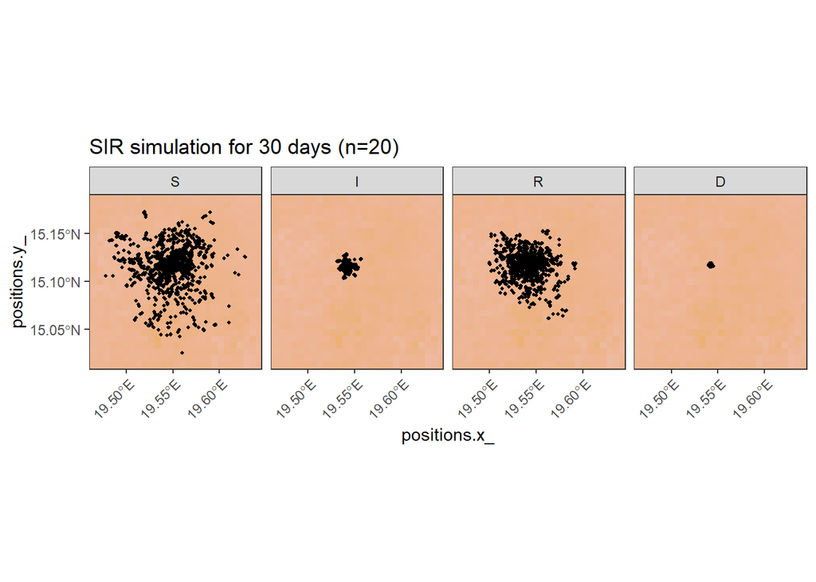

```r
p
```